# Week 27 One-Way ANOVA

Dinkar Sharma, Lazaros Gonidis

31/01/2022

## Introduction

In today’s session we will carry out a one-way analysis of variance (ANOVA) and do some basic descriptive statistics. As mentioned before there are different ways to carry out an ANOVA but today we will be working with the following packages and functions:

`library(haven) ### used to load SPSS .sav files, read_sav()`  
`library(tidyverse) ### for general purpose functions`  
`library(rstatix) ### used for our ANOVA, anova_test()`  
`library(ggpubr) ### used for graphs such as gghistogram()`

For this example you will need to download the file **oneway.sav** and load into a dataframe. This is a randomly generated datafile that includes three variables. The **participant** is our participant’s id, **group** is our factor with three levels, and **performance** is our dependent variable showing the number of tasks each participant completed in a given time. With the following analysis we want to investigate whether there is a main effect of group.

As always, we start by defining our packages, loading our datafile, and setting factor variables.

```r
library(haven) ### used to load SPSS .sav files, read_sav()
library(tidyverse) ### for general purpose functions
library(rstatix) ### used for our ANOVA, anova_test()
library(ggpubr) ### used for graphs such as gghistogram()

data <- read_sav("oneway.sav")
data
```

```
## # A tibble: 91 x 3
##    participant      group performance
##          <dbl>  <dbl+lbl>       <dbl>
##  1          11 1 [0.0 mg]           6
##  2          12 1 [0.0 mg]           4
##  3          13 1 [0.0 mg]           2
##  4          14 1 [0.0 mg]           3
##  5          15 1 [0.0 mg]           4
##  6          16 1 [0.0 mg]           2
##  7          17 1 [0.0 mg]           4
##  8          18 1 [0.0 mg]           7
##  9          19 1 [0.0 mg]           4
## 10          20 1 [0.0 mg]           3
## # ... with 81 more rows
```

```r
### always remember to set your variables as factors where necessary
data$group <- as.factor(data$group)
```

We then acquire descriptive statistics per level of our factor. We do that by grouping. It might also be a good idea to visually inspect our dependent variable using histograms per factor level.

```r
### get mean and sd for our DV grouped by dosage level
data %>%
  group_by(group) %>%
  get_summary_stats(performance, type = "mean_sd")
```

```
## # A tibble: 3 x 5
##   group variable        n  mean    sd
##   <fct> <chr>       <dbl> <dbl> <dbl>
## 1 1     performance    32  3.25  1.48
## 2 2     performance    32  4.62  1.24
## 3 3     performance    27  1.96  1.4
```

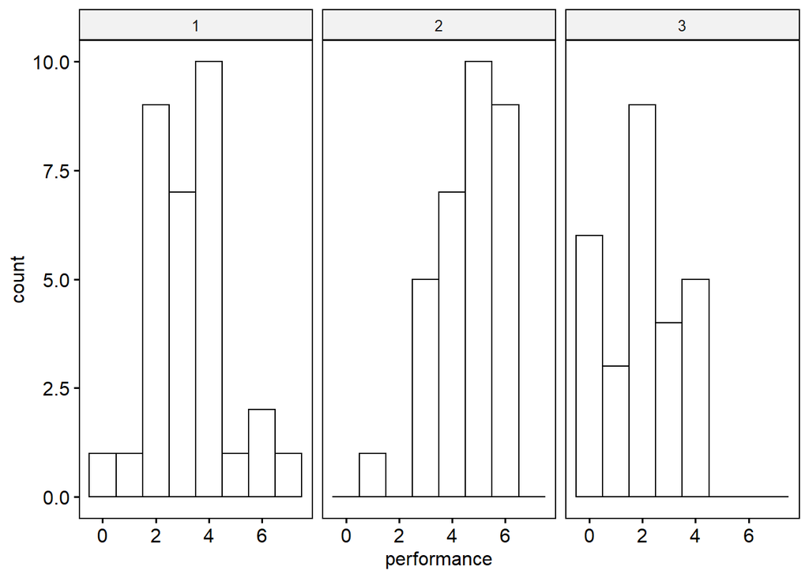

```r
### get histograms if you want to inspect visually

gghistogram(data, x = "performance", facet.by = "group", bins = 8)
```

Before we can acquire our ANOVA output we have to define our analysis model. In this case we will use the function **anova_test()** and we will assign the model to an object of our choice (e.g., anova.model). With **anova_test()** we have to declare the data, the DV, the participants id variable, and our between or within participants factor. In this example we only have a between variable. We also declare that we want our **error** to be of type III. Once we build our model we then can request the output by using **get_anova_table()**

```r
## anova time
# first describe the model
anova.model <- anova_test(
  data = data,
  dv = performance,
  wid = participant,  ## this is our participant id variable
  between = group,
  type = 3,
  detailed = TRUE
)

# then get the anova table
get_anova_table(anova.model)
```

```
## ANOVA Table (type III tests)
##
##        Effect     SSn     SSd DFn DFd       F        p p<.05   ges
## 1 (Intercept) 972.357 166.463   1  88 514.033 1.64e-38     * 0.854
## 2       group 104.284 166.463   2  88  27.565 5.07e-10     * 0.385
```

Refering back to your lecture slides, we also talked about **mean squared error**, **MSE**. This is a value that get_anova_table() does not generate by default by we can produce it by calculated the ratio of SSd by DFd.

```r
## You can manually calculate the MSE by dividing
## SSd and DFd. Make sure you specify the second line
## of your anova.model by typing [2,]
MSE <- anova.model[2,"SSd"]/(anova.model[2,"DFd"])
MSE
```

```
## [1] 1.891625
```

## The Study

For this exercise we are going to look at an experiment involving mice given different levels of a drug to see if their memory (of how to get through a maze) is affected. The data file that we are going to use for task 1 of this exercise is **epinex6.sav** (found in the MOODLE-SP500-COMPUTING-data files). This data file has three columns. **SNO**, **DOSAGE** and **ERRORS**. These columns represent the subject number (in this case mouse number), dosage level of a drug called Epinephrine and how many errors (wrong turns) each mouse made in a maze that they had learnt previously. The experimenter hypothesised that a small amount of the Epinephrine (300mg) would improve the mice’s memory and subsequent performance but a very large amount (1000mg) would impair their memory and performance would deteriorate. In the experiment there were three conditions. A control condition where mice were not given any Epinephrine (this condition is labelled “1” in the DOSAGE column), a condition where a different set of mice were given 300mg before being placed in the maze (labelled “2” in DOSAGE) and the final condition where the dosage was 1000mg (labelled “3” in DOSAGE). Each mouse was randomly allocated to one of these three conditions.

Q1) Produce table of means, standard deviations, and N’s of the three conditions that the analysis compares.  
Q2) Produce the summary table of the Analysis of Variance.  
Q3) From the summary-table, what is the F-value and the p-value?  
Q4) Is there a significant difference between the dosage conditions?  
Q5) Has the experimenter’s hypothesis been supported? Why or Why not?  
Q6) From the histograms alone, describe the different effects of the drugs on each group.  
Q7) Calculate and report your MSE value?

### Task 2

The investigator who carried out the experiment in task 1 using mice, replicated it this time using rats. Data for this replicated study can be found in the data file **epinex62.sav**. Open this file and carry out the same analysis as task 1 (Histograms, ANOVA and descriptives) but this time using the new data. Note that the variable names are now in uppercase letters. This is actually not recommended and you should always use lowercase letters.

Q1) Produce means, standard deviations, and N’s of the three conditions that the analysis compares.  
Q2) Produce a summary table of the Analysis of Variance.  
Q3) From the summary-table, what is the F-value and the p-value?  
Q4) Is there a significant difference between the DOSAGE conditions?  
Q5) Has the experimenter’s hypothesis been supported? Why or Why not?  
Q6) From the histograms alone, describe the different effect of the drugs on each group.  
Q7) Calculate and report your MSE value?

## Task 1 Solution

```r
library(haven)
library(tidyverse)
library(rstatix)
library(ggpubr)

df <- read_sav("epinex6.sav")
df
```

```
## # A tibble: 121 x 3
##      sno     dosage errors
##    <dbl>  <dbl+lbl>  <dbl>
##  1     1 1 [0.0 mg]      0
##  2     2 1 [0.0 mg]      3
##  3     3 1 [0.0 mg]      4
##  4     4 1 [0.0 mg]      2
##  5     5 1 [0.0 mg]      3
##  6     6 1 [0.0 mg]      3
##  7     7 1 [0.0 mg]      4
##  8     8 1 [0.0 mg]      0
##  9     9 1 [0.0 mg]      5
## 10    10 1 [0.0 mg]      4
## # ... with 111 more rows
```

```r
### always remember to set your variables as factors where necessary
df$dosage <- as.factor(df$dosage)

### Question 1
### get mean and sd for our DV grouped by dosage level
df %>%
  group_by(dosage) %>%
  get_summary_stats(errors, type = "mean_sd")
```

```
## # A tibble: 3 x 5
##   dosage variable     n  mean    sd
##   <fct>  <chr>    <dbl> <dbl> <dbl>
## 1 1      errors      42  3.14  1.52
## 2 2      errors      42  4.81  1.25
## 3 3      errors      37  2.11  1.50
```

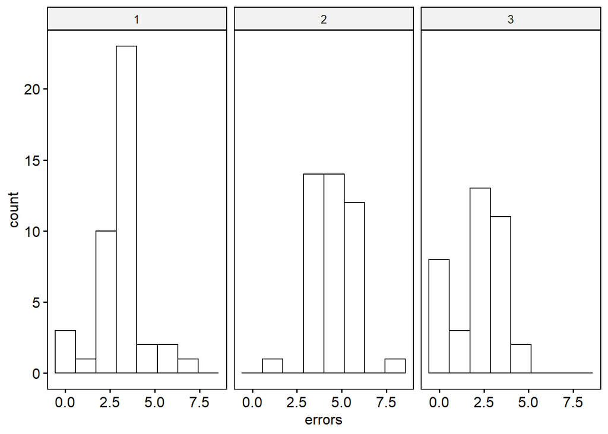

```r
### get histograms

gghistogram(df, x = "errors", facet.by = "dosage", bins = 8)
```

```r
## anova time
# first describe the model
anova.model <- anova_test(
  data = df,
  dv = errors,
  wid = sno,  ## this is our participant id variable
  between = dosage,
  type = 3,
  detailed = TRUE
)
```

```
## Coefficient covariances computed by hccm()
```

```r
# Question 2
# then get the anova table
get_anova_table(anova.model)
```

```
## ANOVA Table (type III tests)
##
##        Effect      SSn     SSd DFn DFd       F        p p<.05   ges
## 1 (Intercept) 1355.911 241.187   1 118 663.376 2.90e-50     * 0.849
## 2      dosage  147.970 241.187   2 118  36.197 5.51e-13     * 0.380
```

```r
## You can manually calculate the MSE by dividing
## SSd and DFd. Make sure you specify the second line
## of your anova.model by typing [2,]
MSE <- anova.model[2,"SSd"]/(anova.model[2,"DFd"])
MSE
```

```
## [1] 2.043958
```

Q1 and Q2 look at code above  
Q3) *F* = 36.197, *p* = 5.51^{-13}  
Q4) Yes  
Q5) No, while there are differences amongst the cell means, the pattern is inconsistent with the experimenter’s hypotheses. Performance appears to have declined (i.e. more errors) in the 300mg condition and improved (i.e. fewer errors) in the 1000mg condition. However, follow-up analyses are needed to discern if these changes differ significantly from the control condition.  
Q6) 300mg seem to be normally distributed with 0mg and 1000mg looking more positively skewed. Mean number of errors is lowest in the 1000mg condition and highest in the 300mg condition.

## Task 2 Solution

```r
library(haven)
library(tidyverse)
library(rstatix)
library(ggpubr)

df2 <- read_sav("epinex62.sav")
df2
```

```
## # A tibble: 121 x 3
##      SNO     DOSAGE ERRORS
##    <dbl>  <dbl+lbl>  <dbl>
##  1     1 1 [0.0 mg]      9
##  2     2 1 [0.0 mg]      3
##  3     3 1 [0.0 mg]      1
##  4     4 1 [0.0 mg]      7
##  5     5 1 [0.0 mg]      3
##  6     6 1 [0.0 mg]      3
##  7     7 1 [0.0 mg]      7
##  8     8 1 [0.0 mg]      7
##  9     9 1 [0.0 mg]      5
## 10    10 1 [0.0 mg]      4
## # ... with 111 more rows
```

```r
### always remember to set your variables as factors where necessary
df2$DOSAGE <- as.factor(df2$DOSAGE)


### Question 1
### get mean and sd for our DV grouped by dosage level
df2 %>%
  group_by(DOSAGE) %>%
  get_summary_stats(ERRORS, type = "mean_sd")
```

```
## # A tibble: 3 x 5
##   DOSAGE variable     n  mean    sd
##   <fct>  <chr>    <dbl> <dbl> <dbl>
## 1 1      ERRORS      42  5    2.20
## 2 2      ERRORS      42  5    0.765
## 3 3      ERRORS      37  5.16 2.89
```

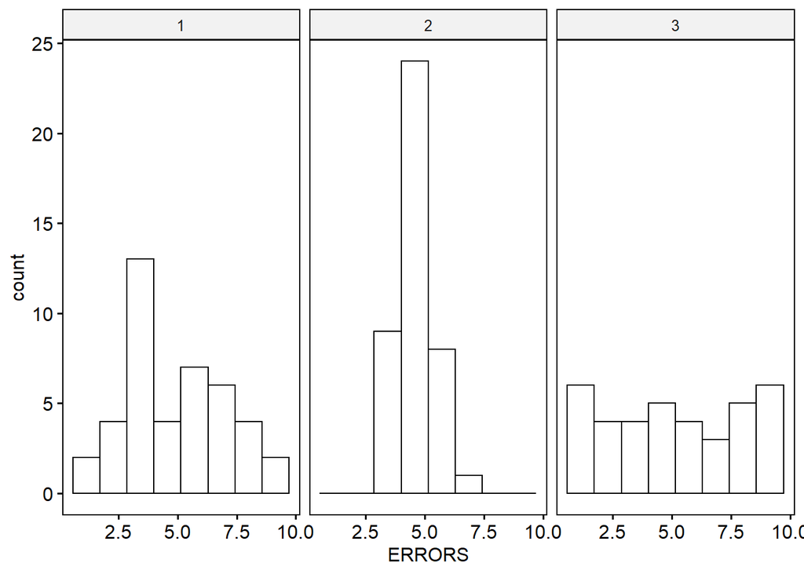

```r
### get histograms

gghistogram(df2, x = "ERRORS", facet.by = "DOSAGE", bins = 8)
```

```r
## anova time
# first describe the model
anova.model2 <- anova_test(
  data = df2,
  dv = ERRORS,
  wid = SNO,  ## this is our participant id variable
  between = DOSAGE,
  type = 3,
  detailed = TRUE
)
```

```
## Coefficient covariances computed by hccm()
```

```r
### Question 2
# then get the anova table
get_anova_table(anova.model2)
```

```
## ANOVA Table (type III tests)
##
##        Effect      SSn     SSd DFn DFd       F        p p<.05   ges
## 1 (Intercept) 3079.749 523.027   1 118 694.821 2.82e-51     * 0.855
## 2      DOSAGE    0.675 523.027   2 118   0.076 9.27e-01       0.001
```

```r
## You can manually calculate the MSE by dividing
## SSd and DFd. Make sure you specify the second line
## of your anova.model by typing [2,]
MSE <- anova.model2[2,"SSd"]/(anova.model2[2,"DFd"])
MSE
```

```
## [1] 4.432432
```

Q1 and Q2 look at code above

Q3) *F* = 0.076, *p* = 0.927  
Q4) No  
Q5) No, there are no significant mean differences, which is inconsistent with the experimenter’s hypotheses.  
Q6) 300mg look to be normally distributed, with 0mg positively skewed. 1000mg seems to be be uniform or even better a bimodal distribution.